# Homework 4

Emirhan Bugday

December 19, 2018

## DataSets

Following datasets are acquired from the UCI machine learning repository (http://archive.ics.uci.edu/ml/datasets.html).

### Student Performance

**Data Set Characteristics:** Multivariate

**Number of Instances:** 649

**Area:** Social

**Attribute Characteristics:** Numeric, categorical, ordinal

**Number of Attributes:** 33

**Date Donated:** 2014-11-27

**Associated Tasks:** Classification, Regression

**Missing Values:** N/A

**Data Set Information:**

This data approach student achievement in secondary education of two Portuguese schools. The data attributes include student grades, demographic, social and school related features) and it was collected by using school reports and questionnaires. Two datasets are provided regarding the performance in two distinct subjects: Mathematics (mat) and Portuguese language (por). In [Cortez and Silva, 2008], the two datasets were modeled under binary/five-level classification and regression tasks. Important note: the target attribute G3 has a strong correlation with attributes G2 and G1. This occurs because G3 is the final year grade (issued at the 3rd period), while G1 and G2 correspond to the 1st and 2nd period grades. It is more difficult to predict G3 without G2 and G1, but such prediction is much more useful (see paper source for more details).

**Attribute Information:**

1 school - student’s school (binary: ‘GP’ - Gabriel Pereira or ‘MS’ - Mousinho da Silveira)

2 sex - student’s sex (binary: ‘F’ - female or ‘M’ - male)

3 age - student’s age (numeric: from 15 to 22)

4 address - student’s home address type (binary: ‘U’ - urban or ‘R’ - rural)

5 famsize - family size (binary: ‘LE3’ - less or equal to 3 or ‘GT3’ - greater than 3)

6 Pstatus - parent’s cohabitation status (binary: ‘T’ - living together or ‘A’ - apart)

7 Medu - mother’s education (numeric: 0 - none, 1 - primary education (4th grade), 2 â???" 5th to 9th grade, 3 â???" secondary education or 4 â???" higher education)

8 Fedu - father’s education (numeric: 0 - none, 1 - primary education (4th grade), 2 â???" 5th to 9th grade, 3 â???" secondary education or 4 â???" higher education)

9 Mjob - mother’s job (nominal: ‘teacher’, ‘health’ care related, civil ‘services’ (e.g. administrative or police), ‘at_home’ or ‘other’)

10 Fjob - father’s job (nominal: ‘teacher’, ‘health’ care related, civil ‘services’ (e.g. administrative or police), ‘at_home’ or ‘other’)

11 reason - reason to choose this school (nominal: close to ‘home’, school ‘reputation’, ‘course’ preference or ‘other’)

12 guardian - student’s guardian (nominal: ‘mother’, ‘father’ or ‘other’)

13 traveltime - home to school travel time (numeric: 1 - <15 min., 2 - 15 to 30 min., 3 - 30 min. to 1 hour, or 4 - >1 hour)

14 studytime - weekly study time (numeric: 1 - <2 hours, 2 - 2 to 5 hours, 3 - 5 to 10 hours, or 4 - >10 hours)

15 failures - number of past class failures (numeric: n if 1<=n<3, else 4)

16 schoolsup - extra educational support (binary: yes or no)

17 famsup - family educational support (binary: yes or no)

18 paid - extra paid classes within the course subject (Math or Portuguese) (binary: yes or no)

19 activities - extra-curricular activities (binary: yes or no)

20 nursery - attended nursery school (binary: yes or no)

21 higher - wants to take higher education (binary: yes or no)

22 internet - Internet access at home (binary: yes or no)

23 romantic - with a romantic relationship (binary: yes or no)

24 famrel - quality of family relationships (numeric: from 1 - very bad to 5 - excellent)

25 freetime - free time after school (numeric: from 1 - very low to 5 - very high)

26 goout - going out with friends (numeric: from 1 - very low to 5 - very high)

27 Dalc - workday alcohol consumption (numeric: from 1 - very low to 5 - very high)

28 Walc - weekend alcohol consumption (numeric: from 1 - very low to 5 - very high)

29 health - current health status (numeric: from 1 - very bad to 5 - very good)

30 absences - number of school absences (numeric: from 0 to 93)

31 G1 - first period grade (numeric: from 0 to 20)

31 G2 - second period grade (numeric: from 0 to 20)

32 G3 - final grade (numeric: from 0 to 20, output target)

### Breast Cancer Wisconsin

**Data Set Characteristics:** Multivariate

**Number of Instances:** 569

**Area:** Life

**Attribute Characteristics:** Real

**Number of Attributes:** 32

**Date Donated:** 1995-11-01

**Associated Tasks:** Classification

**Missing Values:** No

**Data Set Information:**

Each record represents follow-up data for one breast cancer case. These are consecutive patients seen by Dr. Wolberg since 1984, and include only those cases exhibiting invasive breast cancer and no evidence of distant metastases at the time of diagnosis.

```
The first 30 features are computed from a digitized image of a
fine needle aspirate (FNA) of a breast mass.  They describe
characteristics of the cell nuclei present in the image.
A few of the images can be found at (http://www.cs.wisc.edu/~street/images/)
```

**Attribute Information:**

1. ID number
2. Diagnosis (M = malignant, B = benign)
3. -32

Ten real-valued features are computed for each cell nucleus:

1. radius (mean of distances from center to points on the perimeter)
2. texture (standard deviation of gray-scale values)
3. perimeter
4. area
5. smoothness (local variation in radius lengths)
6. compactness (perimeter^2 / area - 1.0)
7. concavity (severity of concave portions of the contour)
8. concave points (number of concave portions of the contour)
9. symmetry
10. fractal dimension (“coastline approximation” - 1)

### Sports Articles for Objectivity Analysis

**Data Set Characteristics:** Multivariate, Text

**Number of Instances:** 1000

**Area:** Social

**Attribute Characteristics:** integer

**Number of Attributes:** 59

**Date Donated:** 2018-04-09

**Associated Tasks:** Classification

**Missing Values:** No

**Data Set Information:**

Some of the features are retrieved using the Stanford POS tagger and the tags are as defined in Penn Treebank Project.

**Attribute Information:**

TextID text file name

URL link to article

Label objective vs. subjective

totalWordsCount total number of words in the article

semanticobjscore Frequency of words with an objective SENTIWORDNET score

semanticsubjscore Frequency of words with a subjective SENTIWORDNET score

CC Frequency of coordinating conjunctions

CD Frequency of numerals and cardinals

DT Frequency of determiners

EX Frequency of existential there

FW Frequency of foreign words

INs Frequency of subordinating preposition or conjunction

JJ Frequency of ordinal adjectives or numerals

JJR Frequency of comparative adjectives

JJS Frequency of superlative adjectives

LS Frequency of list item markers

MD Frequency of modal auxiliaries

NN Frequency of singular common nouns

NNP Frequency of singular proper nouns

NNPS Frequency of plural proper nouns

NNS Frequency of plural common nouns

PDT Frequency of pre-determiners

POS Frequency of genitive markers

PRP Frequency of personal pronouns

PRP$ Frequency of possessive pronouns

RB Frequency of adverbs

RBR Frequency of comparative adverbs

RBS Frequency of superlative adverbs

RP Frequency of particles

SYM Frequency of symbols

TOs Frequency of ‘to’ as preposition or infinitive marker

UH Frequency of interjections

VB Frequency of base form verbs

VBD Frequency of past tense verbs

VBG Frequency of present participle or gerund verbs

VBN Frequency of past participle verbs

VBP Frequency of present tense verbs with plural 3rd person subjects

VBZ Frequency of present tense verbs with singular 3rd person subjects

WDT Frequency of WH-determiners

WP Frequency of WH-pronouns

WP$ Frequency of possessive WH-pronouns

WRB Frequency of WH-adverbs

baseform Frequency of infinitive verbs (base form verbs preceded by â???otoâ???)

Quotes Frequency of quotation pairs in the entire article

questionmarks Frequency of questions marks in the entire article

exclamationmarks Frequency of exclamation marks in the entire article

fullstops Frequency of full stops

commas Frequency of commas

semicolon Frequency of semicolons

colon Frequency of colons

ellipsis Frequency of ellipsis

pronouns1st Frequency of first person pronouns (personal and possessive)

pronouns2nd Frequency of second person pronouns (personal and possessive)

pronouns3rd Frequency of third person pronouns (personal and possessive)

compsupadjadv Frequency of comparative and superlative adjectives and adverbs

past Frequency of past tense verbs with 1st and 2nd person pronouns

imperative Frequency of imperative verbs

present3rd Frequency of present tense verbs with 3rd person pronouns

present1st2nd Frequency of present tense verbs with 1st and 2nd person pronouns

sentence1st First sentence class

sentencelast Last sentence class

txtcomplexity Text complexity score

### Gesture Phase Segmentation

**Data Set Characteristics:** Multivariate, Text

**Number of Instances:** 9900

**Area:** N/A

**Attribute Characteristics:** integer

**Number of Attributes:** 50

**Date Donated:** 2014-06-18

**Associated Tasks:** Classification, Clustering

**Missing Values:** No

**Data Set Information:**

The dataset is composed by features extracted from 7 videos with people gesticulating, aiming at studying Gesture Phase Segmentation.

Each video is represented by two files: a raw file, which contains the position of hands, wrists, head and spine of the user in each frame; and a processed file, which contains velocity and acceleration of hands and wrists. See the data set description for more information on the dataset.

**Attribute Information:**

Raw files: 18 numeric attributes (double), a timestamp and a class attribute (nominal).

Processed files: 32 numeric attributes (double) and a class attribute (nominal).

A feature vector with up to 50 numeric attributes can be generated with the two files mentioned above.

## Methodology

1 - Data is fed in the suitable format

2 - 3 folds of test/train splits are created:

- min of 200 obs or .20 percent of the training data is splitted in each fold
- Stratification w.r.t. Dependent variable is taken into consideration

3 - Parameter Tunning for methods are performed with 5 Fold CV 6 and 2 Resampling:

- 5 Fold-CV is performed for each fold stated in step 2.
- random seed is set for each fold acros the methods to ensure the resamplings will be the same for each model
- Tuned parameters are stated below

### PRA

- lasso penalty is used
- lambda: 0.01 0.06 0.11 0.16 0.21 0.26

### DT

- complexity parameter: 0.01 0.06 0.11 0.16 0.21 0.26

### SVM

1. kernel type -> Polynomial:
- degree
- scale
2. kernel type -> Radial:
- sigma

### RF

- m: 2, 5, 10, 25, 50

### SGB

- depth: 1, 5, 9
- n.trees: 50, 100, 150
- learning rate: 0.05, 0.1, 0.2

## Results

### Student Performance

- Regression Problem

**Overall Test Performance of the Methods (After Parameter Tuning)**

```
##    ModelName  CV_RMSE CV_Rsquared   CV_MAE
## 1:       PRA 2.833549   0.2660581 2.046699
## 2:        DT 2.964267   0.1866754 2.194620
## 3:        RF 2.768300   0.3063744 1.986498
## 4:       GBM 2.770552   0.2964311 2.009769
```

```
##     ModelName Fold     RMSE  Rsquared      MAE
##  1:        DT    1 2.957629 0.1856940 2.205336
##  2:        DT    2 3.029425 0.1868854 2.219057
##  3:        DT    3 2.905748 0.1874468 2.159466
##  4:       GBM    1 2.815641 0.2735623 2.037894
##  5:       GBM    2 2.814049 0.3035164 2.040859
##  6:       GBM    3 2.681965 0.3122145 1.950554
##  7:       PRA    1 2.869637 0.2327437 2.080761
##  8:       PRA    2 2.884017 0.2886570 2.040594
##  9:       PRA    3 2.746991 0.2767736 2.018742
## 10:        RF    1 2.771643 0.3027596 2.003530
## 11:        RF    2 2.845080 0.3044185 2.008375
## 12:        RF    3 2.688176 0.3119450 1.947590
```

#### Fold 1

Parameter tuning results for the methods are provided below

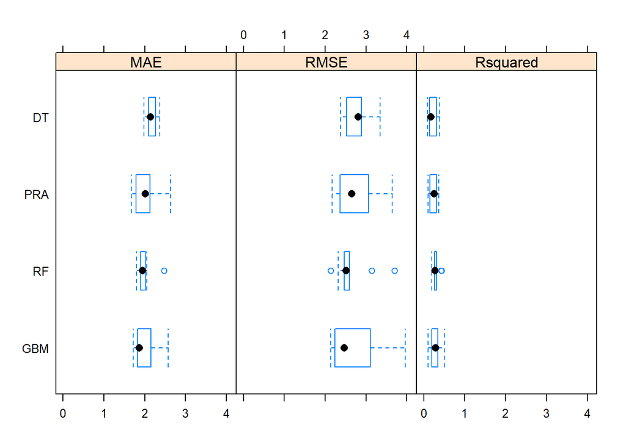

```
## glmnet
##
## 202 samples
##  30 predictor
##
## No pre-processing
## Resampling: Cross-Validated (5 fold, repeated 2 times)
## Summary of sample sizes: 161, 162, 162, 161, 162, 162, ...
## Resampling results across tuning parameters:
##
##   lambda  RMSE      Rsquared   MAE
##   0.01    2.928804  0.1809212  2.207700
##   0.06    2.798359  0.2126556  2.087834
##   0.11    2.740369  0.2288758  2.034906
##   0.16    2.721442  0.2334031  2.015780
##   0.21    2.725905  0.2295122  2.021222
##   0.26    2.733241  0.2261680  2.025848
##
## Tuning parameter 'alpha' was held constant at a value of 1
## RMSE was used to select the optimal model using the smallest value.
## The final values used for the model were alpha = 1 and lambda = 0.16.
```

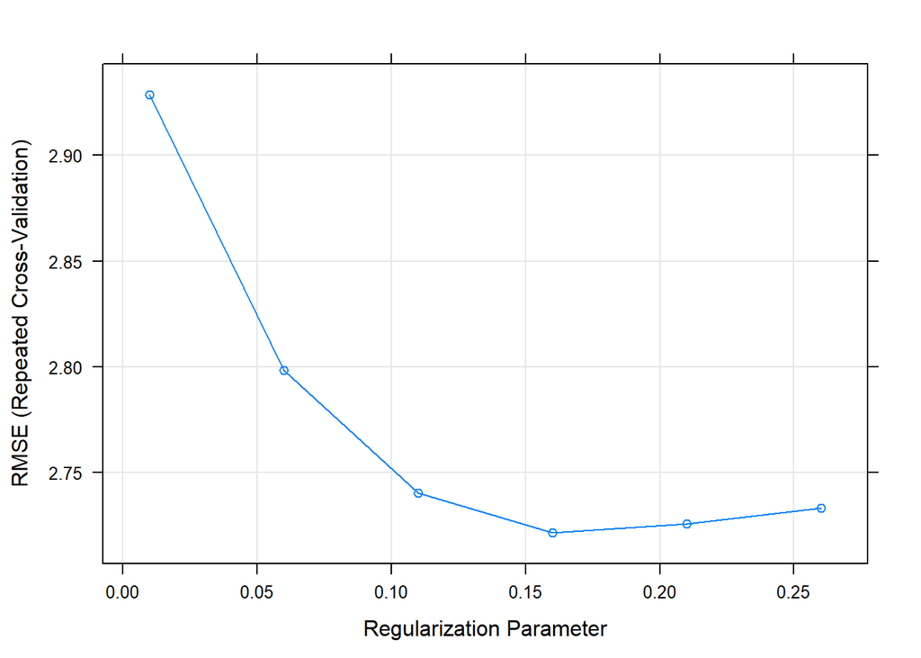

```
## CART
##
## 202 samples
##  30 predictor
##
## No pre-processing
## Resampling: Cross-Validated (5 fold, repeated 2 times)
## Summary of sample sizes: 161, 161, 162, 162, 162, 162, ...
## Resampling results across tuning parameters:
##
##   cp    RMSE      Rsquared   MAE
##   0.01  2.970876  0.1785704  2.223076
##   0.06  2.790979  0.2069873  2.167029
##   0.11  2.794326  0.2114205  2.190955
##   0.16  2.860641  0.1892609  2.222389
##   0.21  3.001450  0.1334005  2.303390
##   0.26  3.105255        NaN  2.361494
##
## RMSE was used to select the optimal model using the smallest value.
## The final value used for the model was cp = 0.06.
```

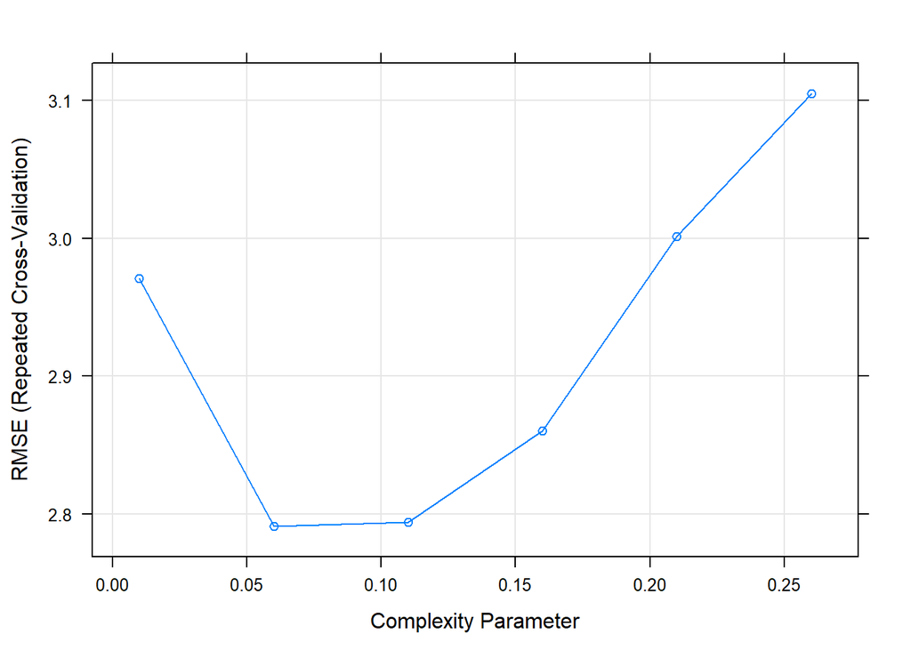

```
## Random Forest
##
## 202 samples
##  30 predictor
##
## No pre-processing
## Resampling: Cross-Validated (5 fold, repeated 2 times)
## Summary of sample sizes: 161, 161, 162, 162, 162, 162, ...
## Resampling results across tuning parameters:
##
##   mtry  RMSE      Rsquared   MAE
##    2    2.718396  0.2889379  2.000400
##    5    2.663471  0.2969324  1.964502
##   10    2.641974  0.2967541  1.983114
##   25    2.704875  0.2630355  2.082403
##   50    2.770772  0.2440631  2.141305
##
## RMSE was used to select the optimal model using the smallest value.
## The final value used for the model was mtry = 10.
```

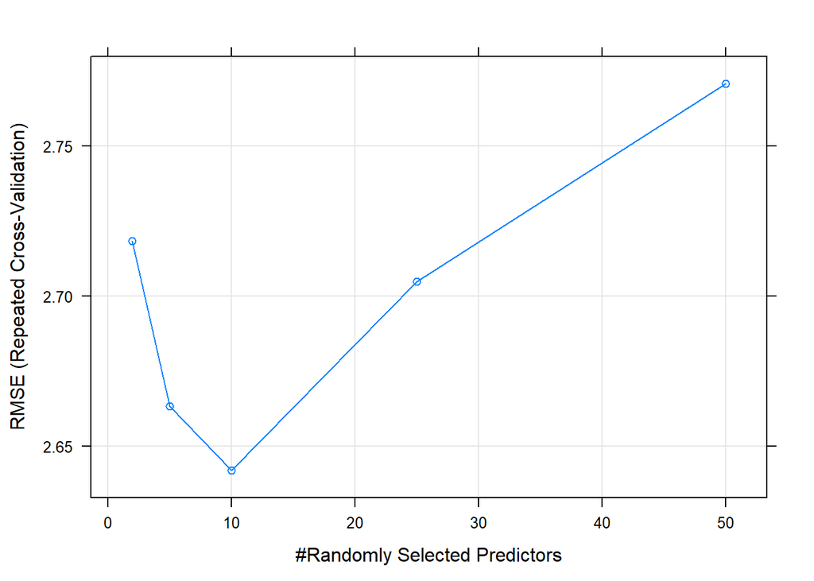

```
## Stochastic Gradient Boosting
##
## 202 samples
##  30 predictor
##
## No pre-processing
## Resampling: Cross-Validated (5 fold, repeated 2 times)
## Summary of sample sizes: 162, 162, 162, 161, 161, 162, ...
## Resampling results across tuning parameters:
##
##   shrinkage  interaction.depth  n.trees  RMSE      Rsquared   MAE
##   0.05       1                   50      2.704460  0.2761683  2.021175
##   0.05       1                  100      2.657349  0.2903274  1.991995
##   0.05       1                  150      2.655021  0.2982399  2.002014
##   0.05       5                   50      2.650730  0.2927640  2.015401
##   0.05       5                  100      2.686977  0.2884187  2.058541
##   0.05       5                  150      2.738641  0.2783142  2.110813
##   0.05       9                   50      2.682312  0.2775868  2.047819
##   0.05       9                  100      2.738131  0.2668393  2.106704
##   0.05       9                  150      2.797543  0.2555779  2.166815
##   0.10       1                   50      2.666803  0.2882385  2.015524
##   0.10       1                  100      2.670716  0.2964724  2.029092
##   0.10       1                  150      2.725253  0.2867016  2.077194
##   0.10       5                   50      2.791978  0.2567778  2.118976
##   0.10       5                  100      2.879620  0.2365252  2.202535
##   0.10       5                  150      2.932914  0.2295185  2.250082
##   0.10       9                   50      2.792086  0.2517452  2.175240
##   0.10       9                  100      2.867873  0.2371171  2.239742
##   0.10       9                  150      2.910243  0.2338924  2.273857
##   0.20       1                   50      2.703965  0.2883628  2.061500
##   0.20       1                  100      2.866157  0.2542320  2.187283
##   0.20       1                  150      2.901701  0.2581913  2.252079
##   0.20       5                   50      2.981783  0.2126603  2.320807
##   0.20       5                  100      3.141167  0.1897723  2.448744
##   0.20       5                  150      3.189519  0.1821197  2.489111
##   0.20       9                   50      3.001935  0.2089490  2.394439
##   0.20       9                  100      3.082117  0.2008274  2.466774
##   0.20       9                  150      3.098337  0.1996895  2.480223
##
## Tuning parameter 'n.minobsinnode' was held constant at a value of 5
## RMSE was used to select the optimal model using the smallest value.
## The final values used for the model were n.trees = 50, interaction.depth
##  = 5, shrinkage = 0.05 and n.minobsinnode = 5.
```

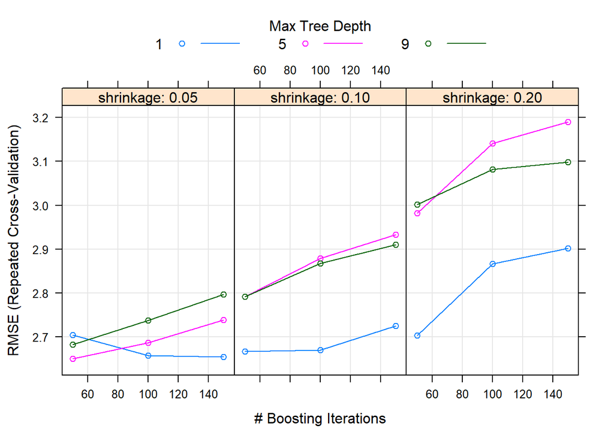

#### Fold 2

Parameter tuning results for the methods are provided below

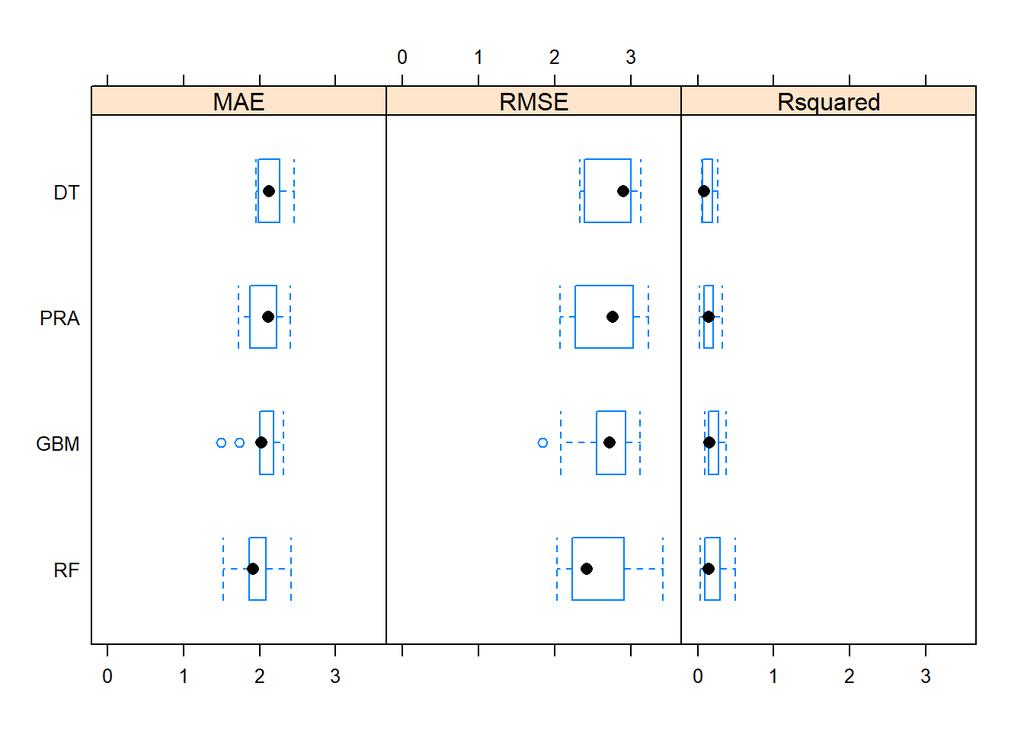

```
## glmnet
##
## 202 samples
##  30 predictor
##
## No pre-processing
## Resampling: Cross-Validated (5 fold, repeated 2 times)
## Summary of sample sizes: 162, 161, 162, 162, 161, 161, ...
## Resampling results across tuning parameters:
##
##   lambda  RMSE      Rsquared    MAE
##   0.01    3.053749  0.09424171  2.374335
##   0.06    2.902970  0.11195942  2.222719
##   0.11    2.806333  0.12827382  2.134970
##   0.16    2.754875  0.13822930  2.098591
##   0.21    2.727783  0.14502511  2.082282
##   0.26    2.711540  0.15124652  2.075404
##
## Tuning parameter 'alpha' was held constant at a value of 1
## RMSE was used to select the optimal model using the smallest value.
## The final values used for the model were alpha = 1 and lambda = 0.26.
```

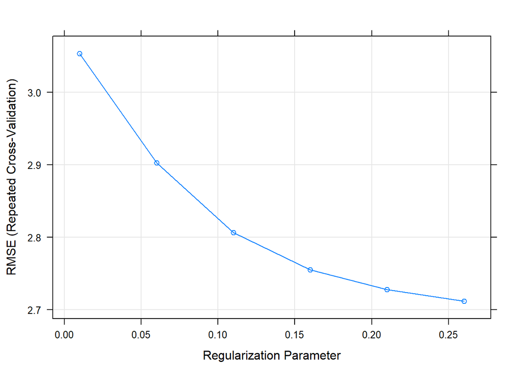

```
## CART
##
## 202 samples
##  30 predictor
##
## No pre-processing
## Resampling: Cross-Validated (5 fold, repeated 2 times)
## Summary of sample sizes: 162, 161, 162, 161, 162, 162, ...
## Resampling results across tuning parameters:
##
##   cp    RMSE      Rsquared   MAE
##   0.01  2.929732  0.1231182  2.204607
##   0.06  2.764433  0.1259681  2.142986
##   0.11  2.802267  0.1055153  2.167876
##   0.16  2.908046        NaN  2.258755
##   0.21  2.908046        NaN  2.258755
##   0.26  2.908046        NaN  2.258755
##
## RMSE was used to select the optimal model using the smallest value.
## The final value used for the model was cp = 0.06.
```

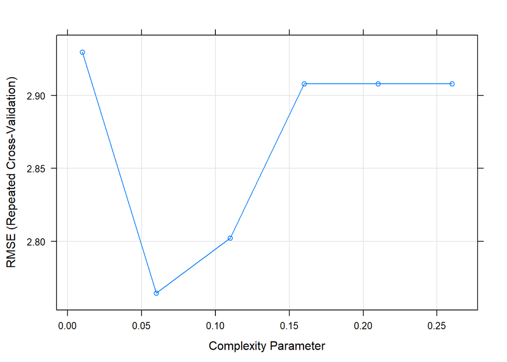

```
## Random Forest
##
## 202 samples
##  30 predictor
##
## No pre-processing
## Resampling: Cross-Validated (5 fold, repeated 2 times)
## Summary of sample sizes: 162, 162, 160, 162, 162, 161, ...
## Resampling results across tuning parameters:
##
##   mtry  RMSE      Rsquared   MAE
##    2    2.651624  0.2072001  2.028613
##    5    2.616571  0.2104062  1.987819
##   10    2.612754  0.2057185  1.964544
##   25    2.649160  0.1879371  1.992928
##   50    2.690642  0.1712774  2.018002
##
## RMSE was used to select the optimal model using the smallest value.
## The final value used for the model was mtry = 10.
```

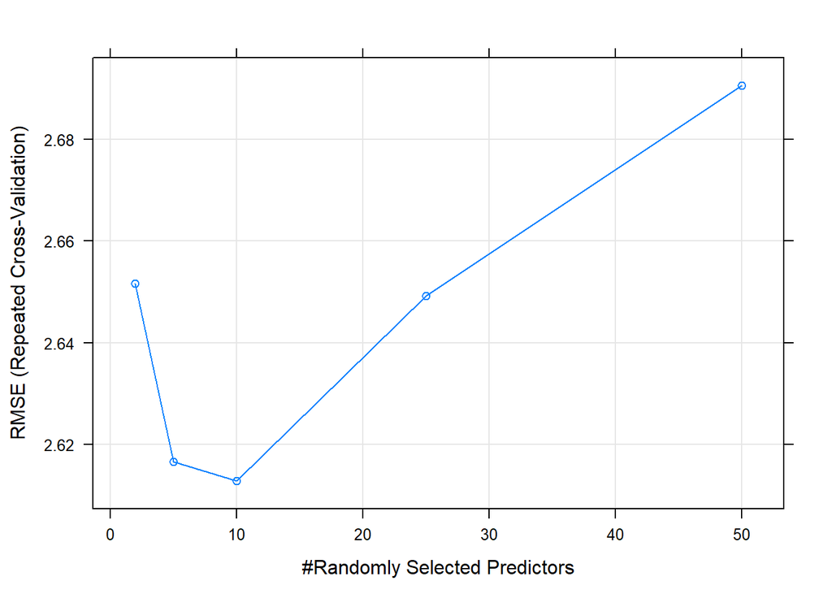

[output not shown]

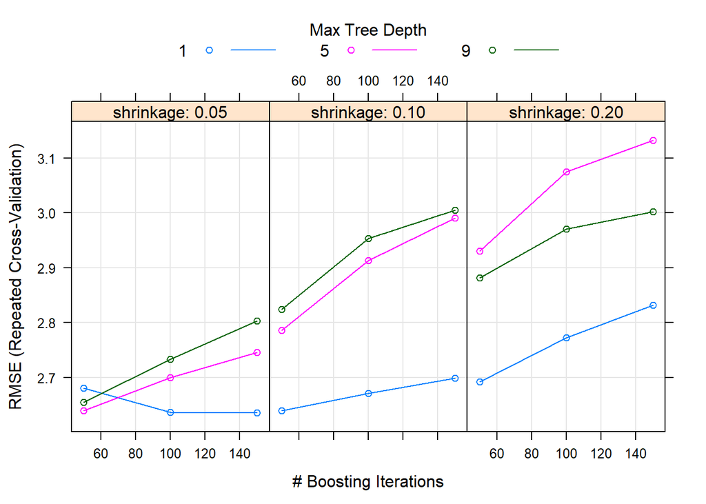

#### Fold 3

Parameter tuning results for the methods are provided below

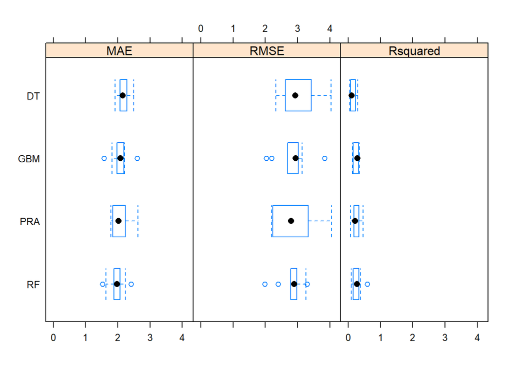

```
## glmnet
##
## 202 samples
##  30 predictor
##
## No pre-processing
## Resampling: Cross-Validated (5 fold, repeated 2 times)
## Summary of sample sizes: 162, 162, 160, 162, 162, 161, ...
## Resampling results across tuning parameters:
##
##   lambda  RMSE      Rsquared   MAE
##   0.01    3.189732  0.1665804  2.379323
##   0.06    3.020095  0.1943122  2.236515
##   0.11    2.928458  0.2146378  2.154287
##   0.16    2.891285  0.2238889  2.112452
##   0.21    2.868921  0.2319819  2.084910
##   0.26    2.858195  0.2378094  2.069967
##
## Tuning parameter 'alpha' was held constant at a value of 1
## RMSE was used to select the optimal model using the smallest value.
## The final values used for the model were alpha = 1 and lambda = 0.26.
```

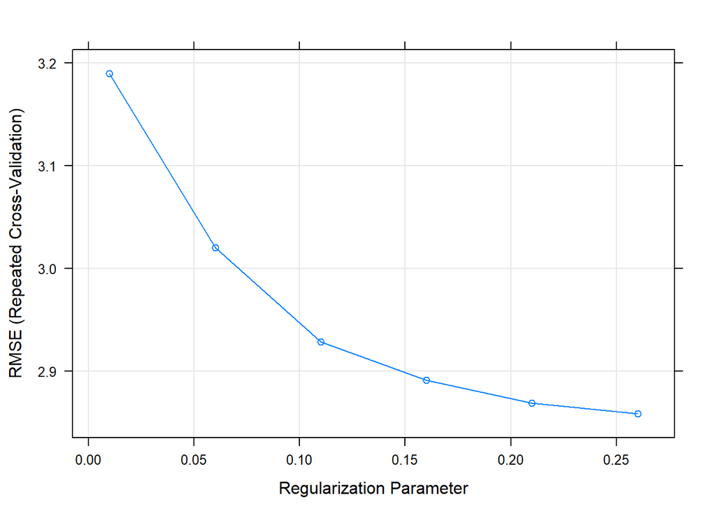

```
## CART
##
## 202 samples
##  30 predictor
##
## No pre-processing
## Resampling: Cross-Validated (5 fold, repeated 2 times)
## Summary of sample sizes: 162, 162, 161, 161, 162, 162, ...
## Resampling results across tuning parameters:
##
##   cp    RMSE      Rsquared    MAE
##   0.01  3.273450  0.10945200  2.405602
##   0.06  3.027406  0.13667302  2.198129
##   0.11  3.189534  0.05914583  2.372367
##   0.16  3.212877         NaN  2.395748
##   0.21  3.212877         NaN  2.395748
##   0.26  3.212877         NaN  2.395748
##
## RMSE was used to select the optimal model using the smallest value.
## The final value used for the model was cp = 0.06.
```

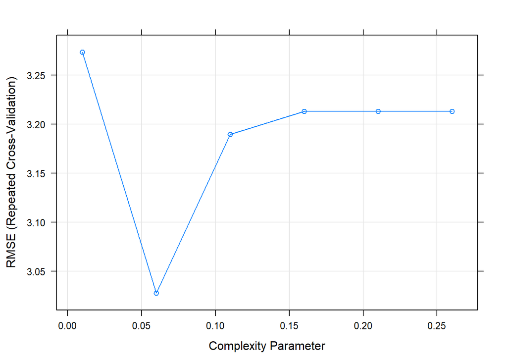

```
## Random Forest
##
## 202 samples
##  30 predictor
##
## No pre-processing
## Resampling: Cross-Validated (5 fold, repeated 2 times)
## Summary of sample sizes: 161, 162, 162, 161, 162, 162, ...
## Resampling results across tuning parameters:
##
##   mtry  RMSE      Rsquared   MAE
##    2    2.880643  0.2767937  2.054458
##    5    2.836821  0.2728867  1.990312
##   10    2.829363  0.2664443  1.971272
##   25    2.839269  0.2609508  2.001646
##   50    2.847821  0.2592122  2.016644
##
## RMSE was used to select the optimal model using the smallest value.
## The final value used for the model was mtry = 10.
```

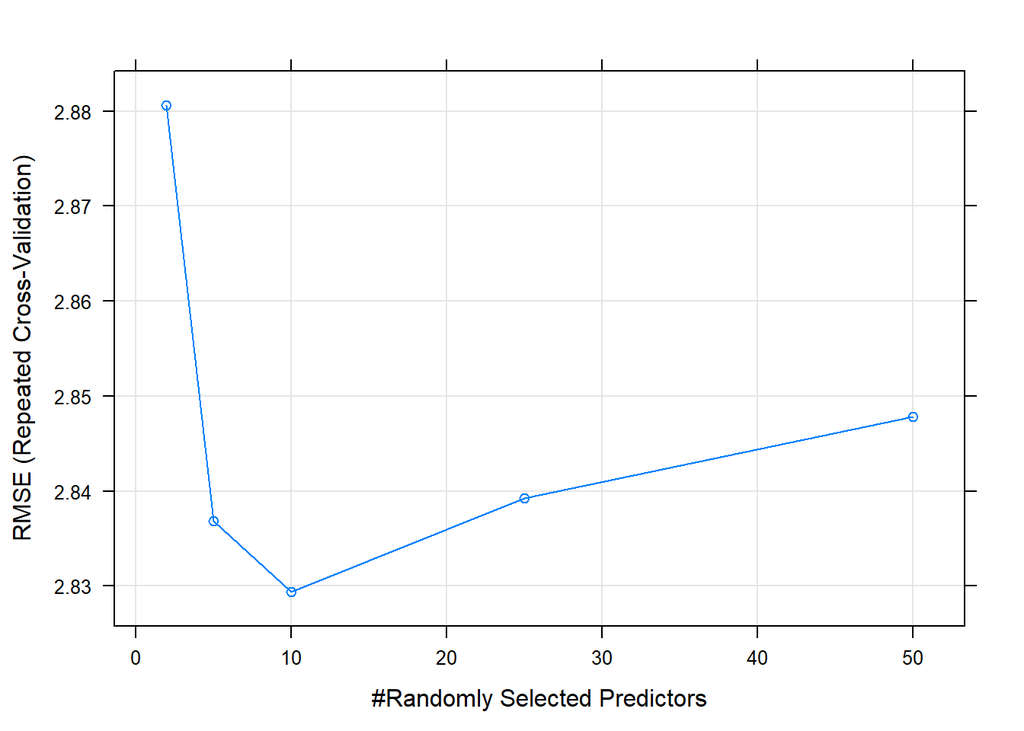

```
## Stochastic Gradient Boosting
##
## 202 samples
##  30 predictor
##
## No pre-processing
## Resampling: Cross-Validated (5 fold, repeated 2 times)
## Summary of sample sizes: 162, 162, 160, 162, 162, 162, ...
## Resampling results across tuning parameters:
##
##   shrinkage  interaction.depth  n.trees  RMSE      Rsquared   MAE
##   0.05       1                   50      2.917013  0.2268831  2.102611
##   0.05       1                  100      2.876786  0.2291559  2.087518
##   0.05       1                  150      2.899250  0.2316072  2.132490
##   0.05       5                   50      2.902349  0.2206527  2.096535
##   0.05       5                  100      2.949252  0.2295046  2.152215
##   0.05       5                  150      3.006409  0.2227410  2.223168
##   0.05       9                   50      2.881413  0.2372890  2.039120
##   0.05       9                  100      2.941273  0.2310029  2.118390
##   0.05       9                  150      3.009778  0.2167943  2.178917
##   0.10       1                   50      2.852469  0.2516379  2.063470
##   0.10       1                  100      2.895824  0.2422382  2.140455
##   0.10       1                  150      2.932780  0.2435546  2.203166
##   0.10       5                   50      3.032917  0.1991801  2.233957
##   0.10       5                  100      3.128039  0.1867911  2.297114
##   0.10       5                  150      3.169353  0.1778357  2.323529
##   0.10       9                   50      3.002960  0.2055443  2.205291
##   0.10       9                  100      3.099703  0.1928229  2.300980
##   0.10       9                  150      3.142262  0.1856479  2.338171
##   0.20       1                   50      2.954634  0.2125102  2.194618
##   0.20       1                  100      3.066299  0.1993738  2.312526
##   0.20       1                  150      3.118647  0.1941479  2.360465
##   0.20       5                   50      3.195663  0.1817904  2.339918
##   0.20       5                  100      3.281494  0.1761510  2.424262
##   0.20       5                  150      3.309541  0.1748498  2.434700
##   0.20       9                   50      3.168218  0.1992927  2.353652
##   0.20       9                  100      3.196453  0.1930543  2.365706
##   0.20       9                  150      3.206694  0.1914000  2.363404
##
## Tuning parameter 'n.minobsinnode' was held constant at a value of 5
## RMSE was used to select the optimal model using the smallest value.
## The final values used for the model were n.trees = 50, interaction.depth
##  = 1, shrinkage = 0.1 and n.minobsinnode = 5.
```

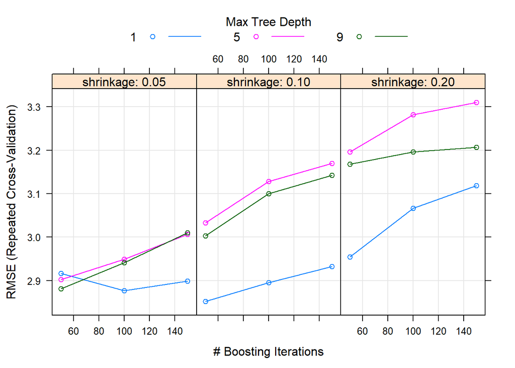

### Breast Cancer Wisconsin

- Classification Problem

**Overall Test Performance of the Methods (After Parameter Tuning)**

[output not shown]

```
##     ModelName Fold  Accuracy     Kappa
##  1:        DT    1 0.9157609 0.8242002
##  2:        DT    2 0.9048913 0.7997761
##  3:        DT    3 0.9076087 0.7956424
##  4:       GBM    1 0.9646739 0.9243038
##  5:       GBM    2 0.9673913 0.9302304
##  6:       GBM    3 0.9592391 0.9118718
##  7:       PRA    1 0.9619565 0.9181156
##  8:       PRA    2 0.9728261 0.9420308
##  9:       PRA    3 0.9701087 0.9353726
## 10:        RF    1 0.9646739 0.9243038
## 11:        RF    2 0.9510870 0.8959636
## 12:        RF    3 0.9510870 0.8934466
```

**Class Distributions:**

```
##
##   B   M
## 357 212
```

#### Fold 1

Parameter tuning results for the methods are provided below

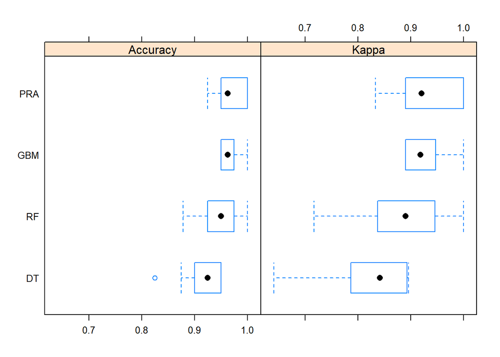

```
## glmnet
##
## 201 samples
##  30 predictor
##   2 classes: 'B', 'M'
##
## No pre-processing
## Resampling: Cross-Validated (5 fold, repeated 2 times)
## Summary of sample sizes: 160, 161, 161, 161, 161, 161, ...
## Resampling results across tuning parameters:
##
##   lambda  Accuracy   Kappa
##   0.01    0.9653049  0.9238976
##   0.06    0.9454878  0.8782374
##   0.11    0.9380488  0.8608444
##   0.16    0.9182317  0.8144066
##   0.21    0.8933537  0.7546743
##   0.26    0.8260976  0.5855504
##
## Tuning parameter 'alpha' was held constant at a value of 1
## Accuracy was used to select the optimal model using the largest value.
## The final values used for the model were alpha = 1 and lambda = 0.01.
```

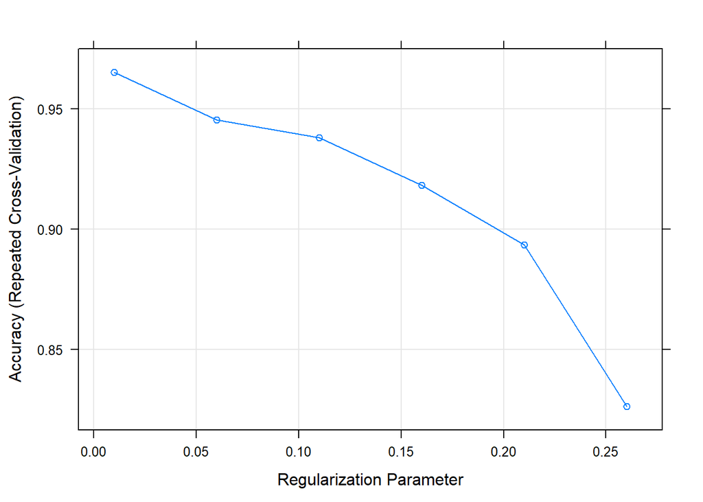

```
## CART
##
## 201 samples
##  30 predictor
##   2 classes: 'B', 'M'
##
## No pre-processing
## Resampling: Cross-Validated (5 fold, repeated 2 times)
## Summary of sample sizes: 161, 161, 161, 161, 160, 160, ...
## Resampling results across tuning parameters:
##
##   cp    Accuracy   Kappa
##   0.01  0.9129268  0.8182907
##   0.06  0.8956098  0.7794194
##   0.11  0.9007317  0.7827908
##   0.16  0.9007317  0.7827908
##   0.21  0.9007317  0.7827908
##   0.26  0.9007317  0.7827908
##
## Accuracy was used to select the optimal model using the largest value.
## The final value used for the model was cp = 0.01.
```

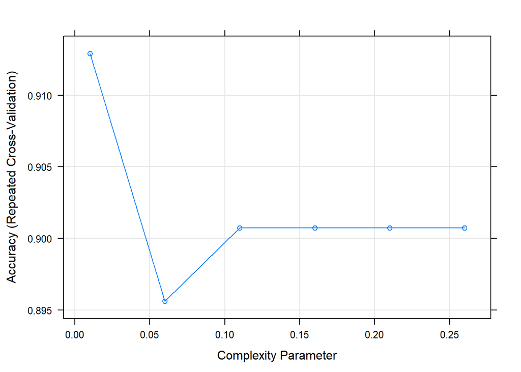

```
## Random Forest
##
## 201 samples
##  30 predictor
##   2 classes: 'B', 'M'
##
## No pre-processing
## Resampling: Cross-Validated (5 fold, repeated 2 times)
## Summary of sample sizes: 161, 160, 161, 161, 161, 161, ...
## Resampling results across tuning parameters:
##
##   mtry  Accuracy   Kappa
##    2    0.9406098  0.8685956
##    5    0.9379878  0.8644740
##   10    0.9330488  0.8533636
##   25    0.9231098  0.8338211
##   50    0.9206707  0.8286581
##
## Accuracy was used to select the optimal model using the largest value.
## The final value used for the model was mtry = 2.
```

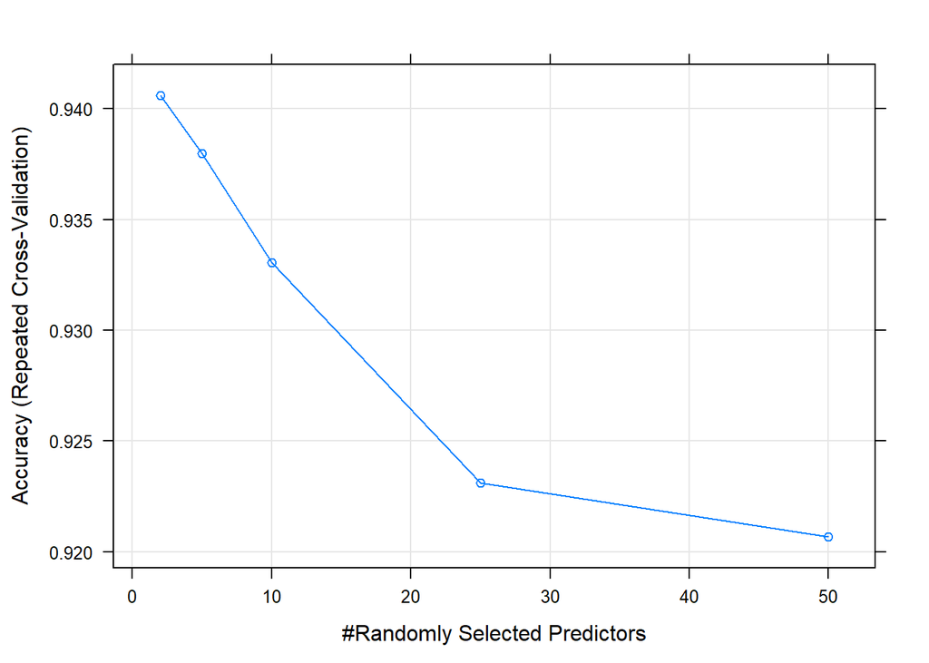

```
## Stochastic Gradient Boosting
##
## 201 samples
##  30 predictor
##   2 classes: 'B', 'M'
##
## No pre-processing
## Resampling: Cross-Validated (5 fold, repeated 2 times)
## Summary of sample sizes: 160, 161, 161, 161, 161, 161, ...
## Resampling results across tuning parameters:
##
##   shrinkage  interaction.depth  n.trees  Accuracy   Kappa
##   0.05       1                   50      0.9204878  0.8256874
##   0.05       1                  100      0.9428659  0.8754471
##   0.05       1                  150      0.9504268  0.8910977
##   0.05       5                   50      0.9329268  0.8553654
##   0.05       5                  100      0.9454268  0.8811681
##   0.05       5                  150      0.9479268  0.8859986
##   0.05       9                   50      0.9279878  0.8427534
##   0.05       9                  100      0.9429268  0.8750397
##   0.05       9                  150      0.9429268  0.8750397
##   0.10       1                   50      0.9503659  0.8925155
##   0.10       1                  100      0.9604268  0.9130238
##   0.10       1                  150      0.9603659  0.9134370
##   0.10       5                   50      0.9479268  0.8861172
##   0.10       5                  100      0.9454268  0.8811641
##   0.10       5                  150      0.9504268  0.8918327
##   0.10       9                   50      0.9454268  0.8811681
##   0.10       9                  100      0.9479268  0.8857044
##   0.10       9                  150      0.9429878  0.8744841
##   0.20       1                   50      0.9653049  0.9241981
##   0.20       1                  100      0.9677439  0.9295557
##   0.20       1                  150      0.9552439  0.9029611
##   0.20       5                   50      0.9429878  0.8747784
##   0.20       5                  100      0.9454878  0.8797454
##   0.20       5                  150      0.9454878  0.8800357
##   0.20       9                   50      0.9553659  0.9030532
##   0.20       9                  100      0.9454268  0.8815017
##   0.20       9                  150      0.9454268  0.8812246
##
## Tuning parameter 'n.minobsinnode' was held constant at a value of 5
## Accuracy was used to select the optimal model using the largest value.
## The final values used for the model were n.trees = 100,
##  interaction.depth = 1, shrinkage = 0.2 and n.minobsinnode = 5.
```

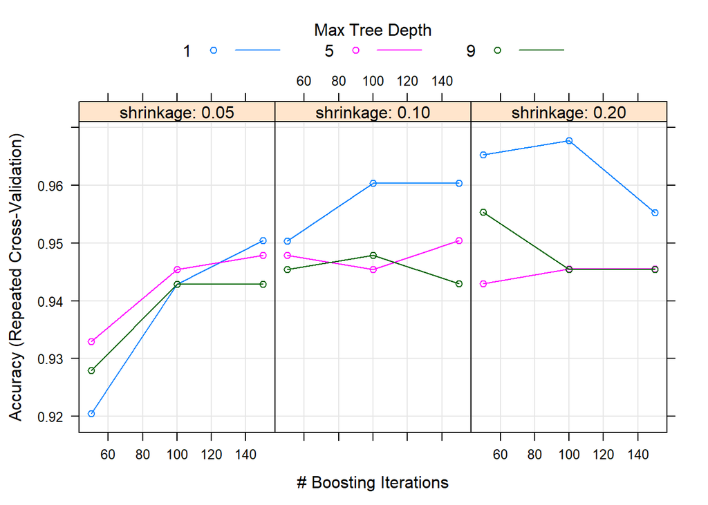

#### Fold 2

Parameter tuning results for the methods are provided below

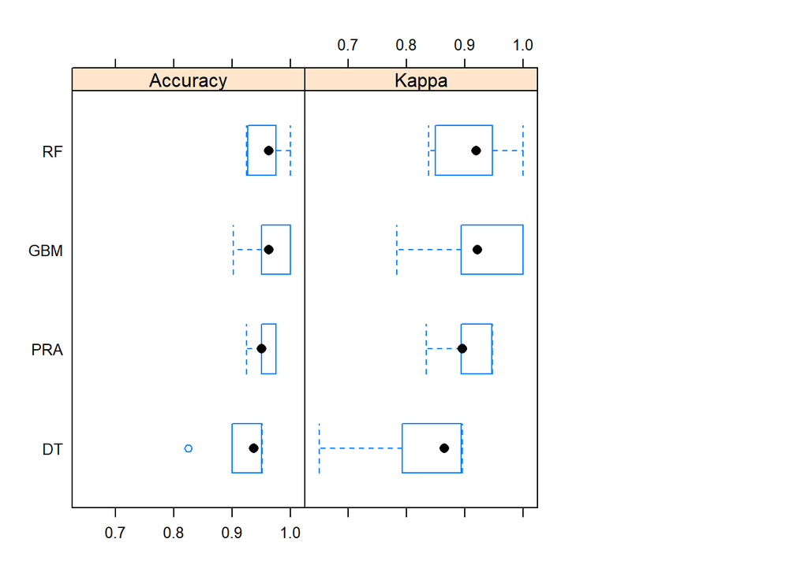

```
## glmnet
##
## 201 samples
##  30 predictor
##   2 classes: 'B', 'M'
##
## No pre-processing
## Resampling: Cross-Validated (5 fold, repeated 2 times)
## Summary of sample sizes: 161, 160, 161, 161, 161, 161, ...
## Resampling results across tuning parameters:
##
##   lambda  Accuracy   Kappa
##   0.01    0.9576829  0.9085908
##   0.06    0.9526829  0.8959901
##   0.11    0.9254268  0.8330609
##   0.16    0.9055488  0.7845829
##   0.21    0.8831707  0.7307421
##   0.26    0.8210366  0.5718356
##
## Tuning parameter 'alpha' was held constant at a value of 1
## Accuracy was used to select the optimal model using the largest value.
## The final values used for the model were alpha = 1 and lambda = 0.01.
```

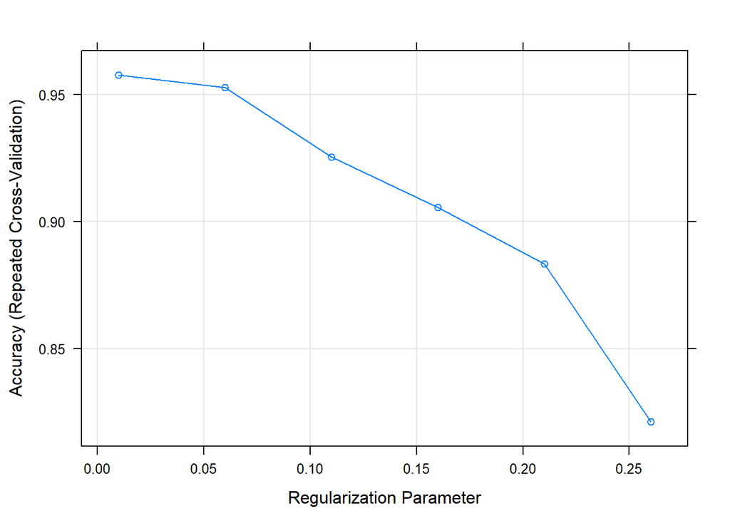

```
## CART
##
## 201 samples
##  30 predictor
##   2 classes: 'B', 'M'
##
## No pre-processing
## Resampling: Cross-Validated (5 fold, repeated 2 times)
## Summary of sample sizes: 161, 161, 161, 160, 161, 161, ...
## Resampling results across tuning parameters:
##
##   cp    Accuracy   Kappa
##   0.01  0.9103049  0.8092103
##   0.06  0.9203659  0.8332692
##   0.11  0.9153659  0.8236687
##   0.16  0.9153659  0.8236687
##   0.21  0.9153659  0.8236687
##   0.26  0.9153659  0.8236687
##
## Accuracy was used to select the optimal model using the largest value.
## The final value used for the model was cp = 0.06.
```

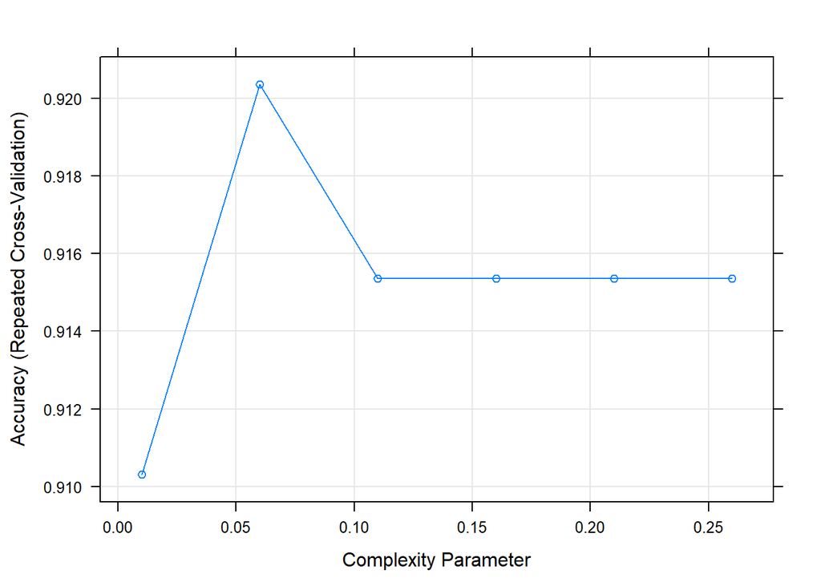

```
## Random Forest
##
## 201 samples
##  30 predictor
##   2 classes: 'B', 'M'
##
## No pre-processing
## Resampling: Cross-Validated (5 fold, repeated 2 times)
## Summary of sample sizes: 161, 160, 161, 161, 161, 161, ...
## Resampling results across tuning parameters:
##
##   mtry  Accuracy   Kappa
##    2    0.9527439  0.8985986
##    5    0.9552439  0.9045788
##   10    0.9577439  0.9099823
##   25    0.9478049  0.8886961
##   50    0.9452439  0.8818936
##
## Accuracy was used to select the optimal model using the largest value.
## The final value used for the model was mtry = 10.
```

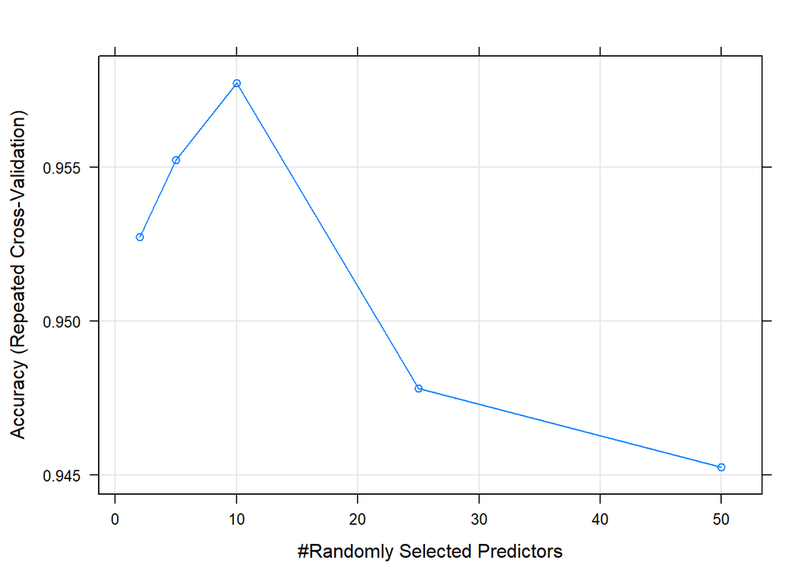

[output not shown]

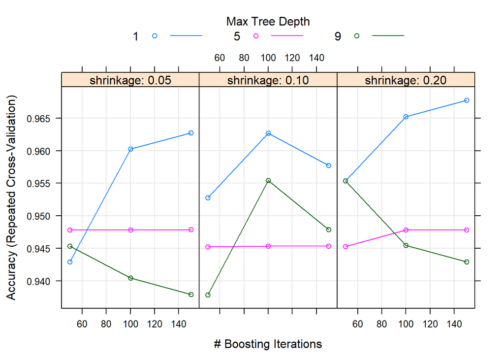

#### Fold 3

Parameter tuning results for the methods are provided below

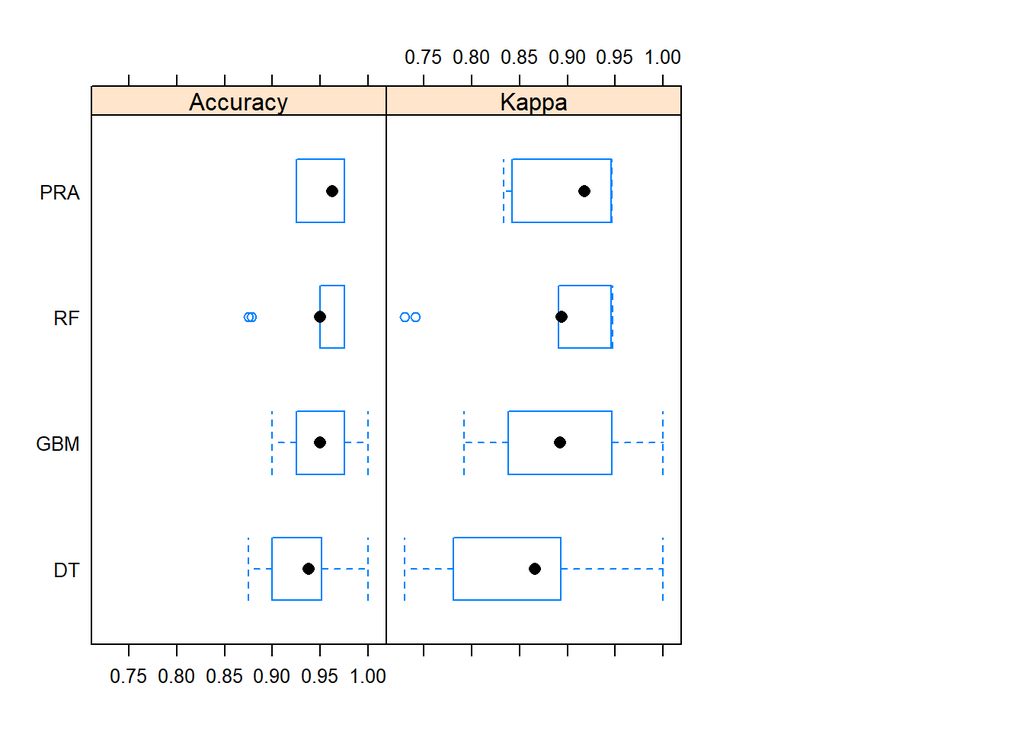

```
## glmnet
##
## 201 samples
##  30 predictor
##   2 classes: 'B', 'M'
##
## No pre-processing
## Resampling: Cross-Validated (5 fold, repeated 2 times)
## Summary of sample sizes: 161, 161, 161, 161, 160, 161, ...
## Resampling results across tuning parameters:
##
##   lambda  Accuracy   Kappa
##   0.01    0.9527439  0.8977813
##   0.06    0.9353049  0.8569075
##   0.11    0.9056707  0.7857564
##   0.16    0.8982927  0.7663709
##   0.21    0.8634756  0.6801383
##   0.26    0.8187195  0.5632608
##
## Tuning parameter 'alpha' was held constant at a value of 1
## Accuracy was used to select the optimal model using the largest value.
## The final values used for the model were alpha = 1 and lambda = 0.01.
```

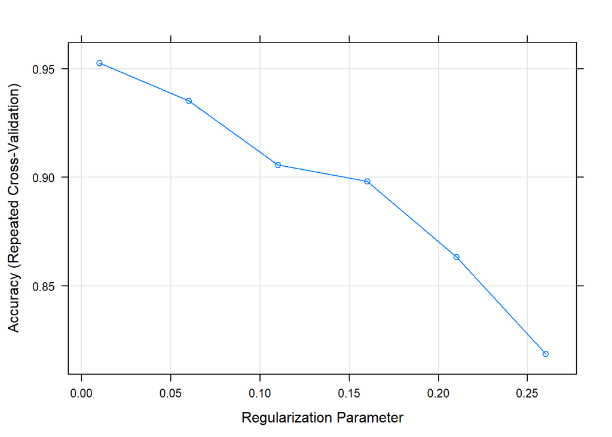

```
## CART
##
## 201 samples
##  30 predictor
##   2 classes: 'B', 'M'
##
## No pre-processing
## Resampling: Cross-Validated (5 fold, repeated 2 times)
## Summary of sample sizes: 161, 161, 161, 160, 161, 161, ...
## Resampling results across tuning parameters:
##
##   cp    Accuracy   Kappa
##   0.01  0.9327439  0.8565636
##   0.06  0.9251829  0.8377813
##   0.11  0.9351829  0.8582887
##   0.16  0.9351829  0.8582887
##   0.21  0.9351829  0.8582887
##   0.26  0.9351829  0.8582887
##
## Accuracy was used to select the optimal model using the largest value.
## The final value used for the model was cp = 0.26.
```

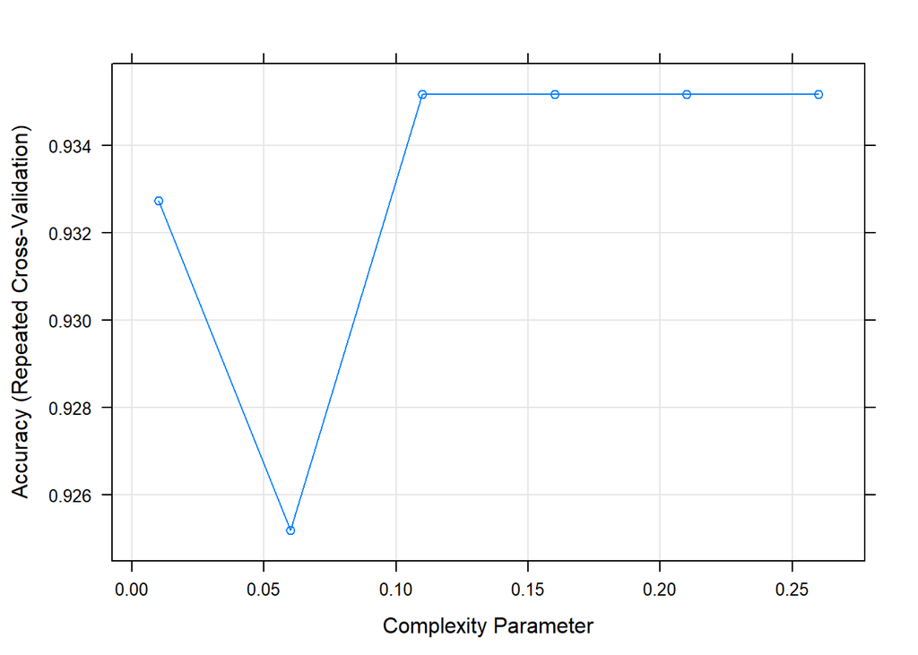

```
## Random Forest
##
## 201 samples
##  30 predictor
##   2 classes: 'B', 'M'
##
## No pre-processing
## Resampling: Cross-Validated (5 fold, repeated 2 times)
## Summary of sample sizes: 161, 161, 161, 161, 160, 160, ...
## Resampling results across tuning parameters:
##
##   mtry  Accuracy   Kappa
##    2    0.9379268  0.8661936
##    5    0.9429268  0.8777878
##   10    0.9403659  0.8730100
##   25    0.9403659  0.8738554
##   50    0.9378659  0.8682984
##
## Accuracy was used to select the optimal model using the largest value.
## The final value used for the model was mtry = 5.
```

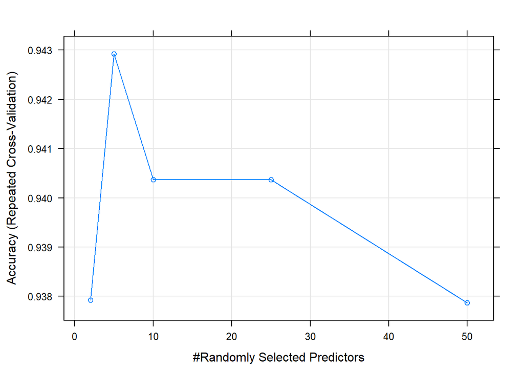

```
## Stochastic Gradient Boosting
##
## 201 samples
##  30 predictor
##   2 classes: 'B', 'M'
##
## No pre-processing
## Resampling: Cross-Validated (5 fold, repeated 2 times)
## Summary of sample sizes: 161, 161, 161, 160, 161, 161, ...
## Resampling results across tuning parameters:
##
##   shrinkage  interaction.depth  n.trees  Accuracy   Kappa
##   0.05       1                   50      0.9177439  0.8210893
##   0.05       1                  100      0.9251829  0.8382818
##   0.05       1                  150      0.9351829  0.8606425
##   0.05       5                   50      0.9352439  0.8614974
##   0.05       5                  100      0.9376829  0.8664847
##   0.05       5                  150      0.9377439  0.8668324
##   0.05       9                   50      0.9327439  0.8556683
##   0.05       9                  100      0.9401829  0.8722263
##   0.05       9                  150      0.9401829  0.8736375
##   0.10       1                   50      0.9451829  0.8824063
##   0.10       1                  100      0.9426829  0.8770065
##   0.10       1                  150      0.9451829  0.8828237
##   0.10       5                   50      0.9376829  0.8668469
##   0.10       5                  100      0.9476829  0.8880794
##   0.10       5                  150      0.9401829  0.8718637
##   0.10       9                   50      0.9451220  0.8833165
##   0.10       9                  100      0.9476829  0.8890723
##   0.10       9                  150      0.9402439  0.8716298
##   0.20       1                   50      0.9401829  0.8723077
##   0.20       1                  100      0.9353049  0.8621866
##   0.20       1                  150      0.9328049  0.8572478
##   0.20       5                   50      0.9252439  0.8396209
##   0.20       5                  100      0.9328049  0.8560008
##   0.20       5                  150      0.9353049  0.8611272
##   0.20       9                   50      0.9351220  0.8642200
##   0.20       9                  100      0.9351829  0.8621614
##   0.20       9                  150      0.9276829  0.8455228
##
## Tuning parameter 'n.minobsinnode' was held constant at a value of 5
## Accuracy was used to select the optimal model using the largest value.
## The final values used for the model were n.trees = 100,
##  interaction.depth = 5, shrinkage = 0.1 and n.minobsinnode = 5.
```

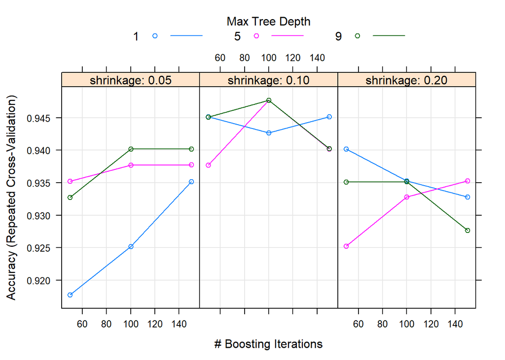

### Sports Articles for Objectivity Analysis

- Classification Problem

**Overall Test Performance of the Methods (After Parameter Tuning)**

```
##    ModelName CV_Accuracy  CV_Kappa
## 1:       PRA   0.8045833 0.5621648
## 2:        RF   0.8058333 0.5832521
## 3:       GBM   0.8087500 0.5910895
```

```
##    ModelName Fold Accuracy     Kappa
## 1:       GBM    1  0.82000 0.6128200
## 2:       GBM    2  0.79875 0.5674252
## 3:       GBM    3  0.80750 0.5930233
## 4:       PRA    1  0.79750 0.5425021
## 5:       PRA    2  0.80375 0.5562841
## 6:       PRA    3  0.81250 0.5877082
## 7:        RF    1  0.81500 0.5991550
## 8:        RF    2  0.80500 0.5799451
## 9:        RF    3  0.79750 0.5706562
```

**Class Distributions:**

```
##
##  objective subjective
##        635        365
```